# Formative Assessment 6

PATAYON, SPIKE LEE-ROY V

2026-04-14

# **Instructions**

1. Download the dataset: **Customer Churn Dataset.**.
2. Perform the analysis using **Python (Jupyter Notebook), R Markdown, or any Markdown-supported environment**.
3. You are required to implement a **Neural Network model** based on the concepts discussed in class (hidden layers, activation functions, SGD, etc.).
4. Clearly show:
   - Code
   - Outputs (tables/plots)
   - Brief explanations (1–3 sentences per task)
5. Submit your work, **group submission allowed, max 2 members per group under FA 6 Group**.
6. File format: **PDF or HTML export** of your notebook/markdown.

```r
library(ggplot2)
library(keras3)
```

# **Assessment Tasks**

## **a. Data Preparation (5 points)**

- Load the dataset and display the first 10 observations.

```r
df = read.csv("C:\\Users\\spike\\Downloads\\WA_Fn-UseC_-Telco-Customer-Churn.csv")

head(df,10)
```

```
##    customerID gender SeniorCitizen Partner Dependents tenure PhoneService
## 1  7590-VHVEG Female             0     Yes         No      1           No
## 2  5575-GNVDE   Male             0      No         No     34          Yes
## 3  3668-QPYBK   Male             0      No         No      2          Yes
## 4  7795-CFOCW   Male             0      No         No     45           No
## 5  9237-HQITU Female             0      No         No      2          Yes
## 6  9305-CDSKC Female             0      No         No      8          Yes
## 7  1452-KIOVK   Male             0      No        Yes     22          Yes
## 8  6713-OKOMC Female             0      No         No     10           No
## 9  7892-POOKP Female             0     Yes         No     28          Yes
## 10 6388-TABGU   Male             0      No        Yes     62          Yes
##       MultipleLines InternetService OnlineSecurity OnlineBackup
## 1  No phone service             DSL             No          Yes
## 2                No             DSL            Yes           No
## 3                No             DSL            Yes          Yes
```

[output cut: 29 more lines]

Quick summary for the whole dataset

```r
summary(df)
```

```
##   customerID           gender          SeniorCitizen      Partner
##  Length:7043        Length:7043        Min.   :0.0000   Length:7043
##  Class :character   Class :character   1st Qu.:0.0000   Class :character
##  Mode  :character   Mode  :character   Median :0.0000   Mode  :character
##                                        Mean   :0.1621
##                                        3rd Qu.:0.0000
##                                        Max.   :1.0000
##
##   Dependents            tenure      PhoneService       MultipleLines
##  Length:7043        Min.   : 0.00   Length:7043        Length:7043
##  Class :character   1st Qu.: 9.00   Class :character   Class :character
##  Mode  :character   Median :29.00   Mode  :character   Mode  :character
##                     Mean   :32.37
##                     3rd Qu.:55.00
##                     Max.   :72.00
##
##  InternetService    OnlineSecurity     OnlineBackup       DeviceProtection
##  Length:7043        Length:7043        Length:7043        Length:7043
##  Class :character   Class :character   Class :character   Class :character
##  Mode  :character   Mode  :character   Mode  :character   Mode  :character
##
##
##
##
##  TechSupport        StreamingTV        StreamingMovies      Contract
##  Length:7043        Length:7043        Length:7043        Length:7043
##  Class :character   Class :character   Class :character   Class :character
##  Mode  :character   Mode  :character   Mode  :character   Mode  :character
##
##
##
##
##  PaperlessBilling   PaymentMethod      MonthlyCharges    TotalCharges
##  Length:7043        Length:7043        Min.   : 18.25   Min.   :  18.8
##  Class :character   Class :character   1st Qu.: 35.50   1st Qu.: 401.4
##  Mode  :character   Mode  :character   Median : 70.35   Median :1397.5
##                                        Mean   : 64.76   Mean   :2283.3
##                                        3rd Qu.: 89.85   3rd Qu.:3794.7
##                                        Max.   :118.75   Max.   :8684.8
##                                                         NA's   :11
##     Churn
##  Length:7043
##  Class :character
##  Mode  :character
##
##
##
##
```

```r
str(df)
```

```
## 'data.frame':    7043 obs. of  21 variables:
##  $ customerID      : chr  "7590-VHVEG" "5575-GNVDE" "3668-QPYBK" "7795-CFOCW" ...
##  $ gender          : chr  "Female" "Male" "Male" "Male" ...
##  $ SeniorCitizen   : int  0 0 0 0 0 0 0 0 0 0 ...
##  $ Partner         : chr  "Yes" "No" "No" "No" ...
##  $ Dependents      : chr  "No" "No" "No" "No" ...
##  $ tenure          : int  1 34 2 45 2 8 22 10 28 62 ...
##  $ PhoneService    : chr  "No" "Yes" "Yes" "No" ...
##  $ MultipleLines   : chr  "No phone service" "No" "No" "No phone service" ...
##  $ InternetService : chr  "DSL" "DSL" "DSL" "DSL" ...
##  $ OnlineSecurity  : chr  "No" "Yes" "Yes" "Yes" ...
##  $ OnlineBackup    : chr  "Yes" "No" "Yes" "No" ...
##  $ DeviceProtection: chr  "No" "Yes" "No" "Yes" ...
##  $ TechSupport     : chr  "No" "No" "No" "Yes" ...
##  $ StreamingTV     : chr  "No" "No" "No" "No" ...
##  $ StreamingMovies : chr  "No" "No" "No" "No" ...
##  $ Contract        : chr  "Month-to-month" "One year" "Month-to-month" "One year" ...
##  $ PaperlessBilling: chr  "Yes" "No" "Yes" "No" ...
##  $ PaymentMethod   : chr  "Electronic check" "Mailed check" "Mailed check" "Bank transfer (automatic)" ...
##  $ MonthlyCharges  : num  29.9 57 53.9 42.3 70.7 ...
##  $ TotalCharges    : num  29.9 1889.5 108.2 1840.8 151.7 ...
##  $ Churn           : chr  "No" "No" "Yes" "No" ...
```

- Identify the **target variable (Churn)**.

```r
table(df$Churn)
```

```
##
##   No  Yes
## 5174 1869
```

- Handle missing values.

```r
colSums(is.na(df))
```

```
##       customerID           gender    SeniorCitizen          Partner
##                0                0                0                0
##       Dependents           tenure     PhoneService    MultipleLines
##                0                0                0                0
##  InternetService   OnlineSecurity     OnlineBackup DeviceProtection
##                0                0                0                0
##      TechSupport      StreamingTV  StreamingMovies         Contract
##                0                0                0                0
## PaperlessBilling    PaymentMethod   MonthlyCharges     TotalCharges
##                0                0                0               11
##            Churn
##                0
```

We have 11 missing values in the column TotalCharges

```r
df$TotalCharges = as.numeric(df$TotalCharges)
df = na.omit(df)
```

```r
colSums(is.na(df))
```

```
##       customerID           gender    SeniorCitizen          Partner
##                0                0                0                0
##       Dependents           tenure     PhoneService    MultipleLines
##                0                0                0                0
##  InternetService   OnlineSecurity     OnlineBackup DeviceProtection
##                0                0                0                0
##      TechSupport      StreamingTV  StreamingMovies         Contract
##                0                0                0                0
## PaperlessBilling    PaymentMethod   MonthlyCharges     TotalCharges
##                0                0                0                0
##            Churn
##                0
```

- Encode categorical variables (e.g., gender, contract type).

  Before we start encoding categorical variables, we must look at the dataset and see what can we fix first

  Convert SeniorCitizen (0/1 → Yes/No)

```r
df$SeniorCitizen = ifelse(df$SeniorCitizen == 1, "Yes", "No")
```

```r
catvar = c("gender", "SeniorCitizen", "Partner", "Dependents",
              "PhoneService", "MultipleLines", "InternetService",
              "OnlineSecurity", "OnlineBackup", "DeviceProtection",
              "TechSupport", "StreamingTV", "StreamingMovies",
              "Contract", "PaperlessBilling", "PaymentMethod", "Churn")

df[catvar] = lapply(df[catvar], as.factor)
```

- Normalize or standardize numerical variables.

```r
numvar = c("tenure", "MonthlyCharges", "TotalCharges")

df[numvar] = scale(df[numvar])
```

```r
head(df)
```

```
##   customerID gender SeniorCitizen Partner Dependents      tenure PhoneService
## 1 7590-VHVEG Female            No     Yes         No -1.28015700           No
## 2 5575-GNVDE   Male            No      No         No  0.06429811          Yes
## 3 3668-QPYBK   Male            No      No         No -1.23941594          Yes
## 4 7795-CFOCW   Male            No      No         No  0.51244982           No
## 5 9237-HQITU Female            No      No         No -1.23941594          Yes
## 6 9305-CDSKC Female            No      No         No -0.99496955          Yes
##      MultipleLines InternetService OnlineSecurity OnlineBackup DeviceProtection
## 1 No phone service             DSL             No          Yes               No
## 2               No             DSL            Yes           No              Yes
## 3               No             DSL            Yes          Yes               No
## 4 No phone service             DSL            Yes           No              Yes
## 5               No     Fiber optic             No           No               No
## 6              Yes     Fiber optic             No           No              Yes
##   TechSupport StreamingTV StreamingMovies       Contract PaperlessBilling
## 1          No          No              No Month-to-month              Yes
## 2          No          No              No       One year               No
## 3          No          No              No Month-to-month              Yes
## 4         Yes          No              No       One year               No
## 5          No          No              No Month-to-month              Yes
## 6          No         Yes             Yes Month-to-month              Yes
##               PaymentMethod MonthlyCharges TotalCharges Churn
## 1          Electronic check     -1.1616113   -0.9941234    No
## 2              Mailed check     -0.2608594   -0.1737275    No
## 3              Mailed check     -0.3638974   -0.9595809   Yes
## 4 Bank transfer (automatic)     -0.7477972   -0.1952338    No
## 5          Electronic check      0.1961642   -0.9403906   Yes
## 6          Electronic check      1.1584066   -0.6453233   Yes
```

Numerical variables are standardized using scaling so that they have mean 0 and standard deviation 1, improving model performance.

## **b. Exploratory Data Analysis (5 points)**

- Create at least **2 visualizations**, such as:
  - Churn distribution

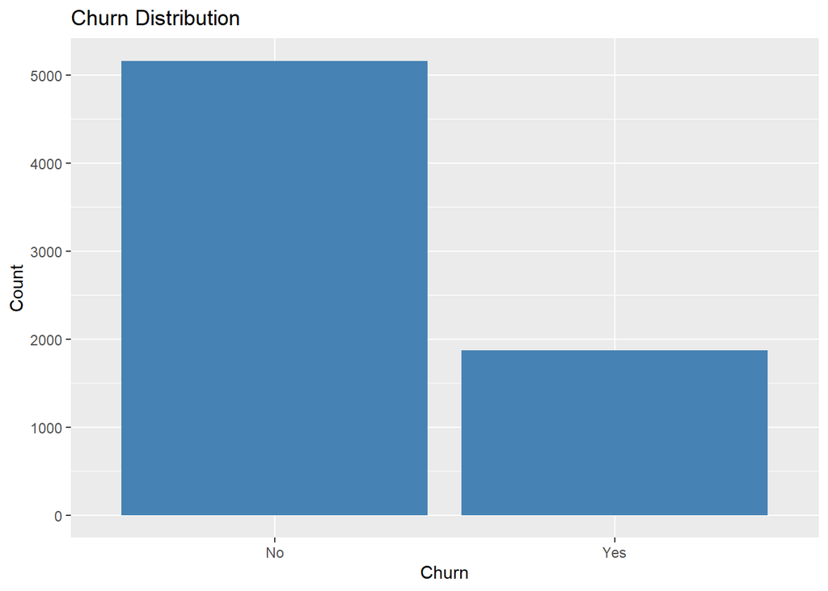

  ```r
  ggplot(df, aes (x = Churn)) +
    geom_bar(fill = "steelblue") +
    labs(title = "Churn Distribution",
    x = "Churn",
    y = "Count")
  ```

  - Monthly charges vs churn

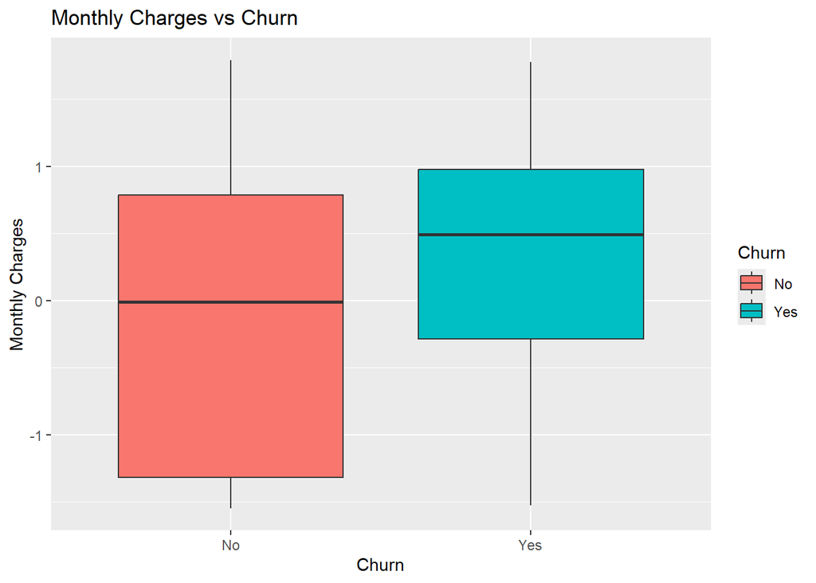

```r
ggplot(df, aes(x = Churn, y = MonthlyCharges, fill = Churn)) +
  geom_boxplot() +
  labs(title = "Monthly Charges vs Churn",
       x = "Churn",
       y = "Monthly Charges")
```

This boxplot compares monthly charges across churn groups to see if higher costs are linked to churn.

- Identify:
  - Class imbalance (if any)
  - At least 2 variables that may influence churn

Some notable findings

1. Class Imbalance
- There is class imbalance, as non-churn customers are typically more frequent than churn customers.
2. Variables Influencing Churn
- MonthlyCharges: Customers with higher charges tend to churn more.
- Contract: Customers with shorter contracts (e.g., month-to-month) are more likely to churn.

## **c. Neural Network Model Construction (8 points)**

- Build a **one-hidden-layer neural network** with:
  - Input layer (features)

  ```r
  # Convert target to numeric (0/1)
  df$Churn <- ifelse(df$Churn == "Yes", 1, 0)

  # Split features and target
  x <- model.matrix(Churn ~ . -1, data = df)
  y <- df$Churn

  # Define model
  model <- keras_model_sequential() %>%
    layer_dense(units = 16, activation = "relu", input_shape = ncol(x)) %>%
    layer_dense(units = 1, activation = "sigmoid")

  # Compile model
  model %>% compile(
    loss = "binary_crossentropy",
    optimizer = "adam",
    metrics = c("accuracy")
  )

  model
  ```

  ```
  ## Model: "sequential"
  ## ┌───────────────────────────────────┬──────────────────────────┬───────────────
  ## │ Layer (type)                      │ Output Shape             │       Param #
  ## ├───────────────────────────────────┼──────────────────────────┼───────────────
  ## │ dense (Dense)                     │ (None, 16)               │       113,008
  ## ├───────────────────────────────────┼──────────────────────────┼───────────────
  ## │ dense_1 (Dense)                   │ (None, 1)                │            17
  ## └───────────────────────────────────┴──────────────────────────┴───────────────
  ##  Total params: 113,025 (441.50 KB)
  ##  Trainable params: 113,025 (441.50 KB)
  ##  Non-trainable params: 0 (0.00 B)
  ```

- Specify:
  - Number of neurons in hidden layer

    **16 neurons**

    **Hidden layer:** ReLU

    **Output layer:** Sigmoid

    **Explanation:** ReLU introduces non-linearity, while Sigmoid outputs probabilities between 0 and 1.
  - Loss function (e.g., binary cross-entropy)

    **Binary Cross-Entropy**

    **Explanation:** This loss function is appropriate for binary classification problems like churn prediction.

## **d. Model Training (5 points)**

- Split the data into **training (80%) and testing (20%)**.

```r
set.seed(123)

train_index <- sample(1:nrow(x), 0.8 * nrow(x))

x_train <- x[train_index, ]
x_test  <- x[-train_index, ]

y_train <- y[train_index]
y_test  <- y[-train_index]
```

- Train the model using:
  - At least **10 epochs**
  - Optimizer such as **Stochastic Gradient Descent (SGD) or Adam**

```r
history <- model %>% fit(
  x_train, y_train,
  epochs = 10,
  batch_size = 32,
  validation_split = 0.2
)
```

```
## 141/141 - 1s - 7ms/step - accuracy: 0.7482 - loss: 0.4994 - val_accuracy: 0.7804 - val_loss: 0.4544
## 141/141 - 0s - 3ms/step - accuracy: 0.7987 - loss: 0.4308 - val_accuracy: 0.7938 - val_loss: 0.4389
## 141/141 - 0s - 3ms/step - accuracy: 0.8096 - loss: 0.4088 - val_accuracy: 0.7964 - val_loss: 0.4332
## 141/141 - 0s - 3ms/step - accuracy: 0.8249 - loss: 0.3859 - val_accuracy: 0.7947 - val_loss: 0.4300
## 141/141 - 0s - 3ms/step - accuracy: 0.8411 - loss: 0.3596 - val_accuracy: 0.7947 - val_loss: 0.4285
## 141/141 - 0s - 3ms/step - accuracy: 0.8627 - loss: 0.3308 - val_accuracy: 0.7938 - val_loss: 0.4285
## 141/141 - 0s - 3ms/step - accuracy: 0.8909 - loss: 0.2956 - val_accuracy: 0.8009 - val_loss: 0.4274
## 141/141 - 0s - 3ms/step - accuracy: 0.9178 - loss: 0.2560 - val_accuracy: 0.7858 - val_loss: 0.4344
## 141/141 - 0s - 3ms/step - accuracy: 0.9542 - loss: 0.2162 - val_accuracy: 0.7956 - val_loss: 0.4267
## 141/141 - 0s - 3ms/step - accuracy: 0.9760 - loss: 0.1754 - val_accuracy: 0.7964 - val_loss: 0.4242
```

- Report:
  - Training loss
  - Accuracy

```r
history$metrics$loss
```

```
##  [1] 0.4993522 0.4308384 0.4088135 0.3859278 0.3596375 0.3308305 0.2956122
##  [8] 0.2560254 0.2161842 0.1753645
```

[output not shown]

[figure not shown]

```r
history$metrics$accuracy
```

## **e. Model Evaluation (4 points)**

- Present:
  - Accuracy score

  ```r
  pred_prob <- model %>% predict(x_test)
  ```

  ```
  ## 44/44 - 0s - 2ms/step
  ```

  ```r
  pred_class <- ifelse(pred_prob > 0.5, 1, 0)

  accuracy <- mean(pred_class == y_test)
  accuracy
  ```

  ```
  ## [1] 0.8187633
  ```

  - Confusion matrix

  ```r
  table(Predicted = pred_class, Actual = y_test)
  ```

  ```
  ##          Actual
  ## Predicted   0   1
  ##         0 951 163
  ##         1  92 201
  ```

- Interpret the results in **2–3 sentences** (e.g., model strengths/weaknesses).

## **f. Model Improvement / Tuning (3 points)**

- Modify at least one parameter:
  - Number of hidden neurons
  - Learning rate
  - Number of epochs

```r
history_tuned <- model %>% fit(
  x_train, y_train,
  epochs = 20,   # increased from 10 → 20
  batch_size = 32,
  validation_split = 0.2
)
```

```
## 141/141 - 0s - 3ms/step - accuracy: 0.9844 - loss: 0.1389 - val_accuracy: 0.7920 - val_loss: 0.4408
## 141/141 - 0s - 3ms/step - accuracy: 0.9913 - loss: 0.1080 - val_accuracy: 0.7929 - val_loss: 0.4345
## 141/141 - 0s - 3ms/step - accuracy: 0.9956 - loss: 0.0834 - val_accuracy: 0.7920 - val_loss: 0.4358
## 141/141 - 0s - 3ms/step - accuracy: 0.9964 - loss: 0.0639 - val_accuracy: 0.7920 - val_loss: 0.4395
## 141/141 - 0s - 3ms/step - accuracy: 0.9982 - loss: 0.0497 - val_accuracy: 0.7929 - val_loss: 0.4351
## 141/141 - 0s - 3ms/step - accuracy: 0.9989 - loss: 0.0391 - val_accuracy: 0.7920 - val_loss: 0.4471
## 141/141 - 0s - 3ms/step - accuracy: 0.9996 - loss: 0.0309 - val_accuracy: 0.7929 - val_loss: 0.4433
## 141/141 - 0s - 3ms/step - accuracy: 0.9996 - loss: 0.0249 - val_accuracy: 0.7902 - val_loss: 0.4531
## 141/141 - 0s - 3ms/step - accuracy: 0.9998 - loss: 0.0202 - val_accuracy: 0.7911 - val_loss: 0.4535
## 141/141 - 0s - 3ms/step - accuracy: 1.0000 - loss: 0.0167 - val_accuracy: 0.7902 - val_loss: 0.4482
## 141/141 - 0s - 3ms/step - accuracy: 1.0000 - loss: 0.0139 - val_accuracy: 0.7929 - val_loss: 0.4480
## 141/141 - 0s - 3ms/step - accuracy: 1.0000 - loss: 0.0116 - val_accuracy: 0.7964 - val_loss: 0.4473
## 141/141 - 0s - 3ms/step - accuracy: 1.0000 - loss: 0.0099 - val_accuracy: 0.7929 - val_loss: 0.4410
## 141/141 - 0s - 3ms/step - accuracy: 1.0000 - loss: 0.0084 - val_accuracy: 0.7929 - val_loss: 0.4491
## 141/141 - 1s - 5ms/step - accuracy: 1.0000 - loss: 0.0072 - val_accuracy: 0.7884 - val_loss: 0.4476
## 141/141 - 1s - 5ms/step - accuracy: 1.0000 - loss: 0.0063 - val_accuracy: 0.7893 - val_loss: 0.4515
## 141/141 - 1s - 5ms/step - accuracy: 1.0000 - loss: 0.0054 - val_accuracy: 0.7964 - val_loss: 0.4399
## 141/141 - 0s - 3ms/step - accuracy: 1.0000 - loss: 0.0048 - val_accuracy: 0.7920 - val_loss: 0.4454
## 141/141 - 0s - 3ms/step - accuracy: 1.0000 - loss: 0.0042 - val_accuracy: 0.7911 - val_loss: 0.4473
## 141/141 - 0s - 3ms/step - accuracy: 1.0000 - loss: 0.0037 - val_accuracy: 0.7911 - val_loss: 0.4459
```

```r
pred_prob_tuned <- model %>% predict(x_test)
```

```
## 44/44 - 0s - 2ms/step
```

```r
pred_class_tuned <- ifelse(pred_prob_tuned > 0.5, 1, 0)

accuracy_tuned <- mean(pred_class_tuned == y_test)
accuracy_tuned
```

```
## [1] 0.8123667
```

- Compare performance before and after tuning

Further improvements such as handling class imbalance or adjusting model architecture are recommended for better performance.